# MasterDoc

## Batch effect pca limma ctrl

#expectation before: clusters of the same batch, strong separation along principle components after: no separation visible

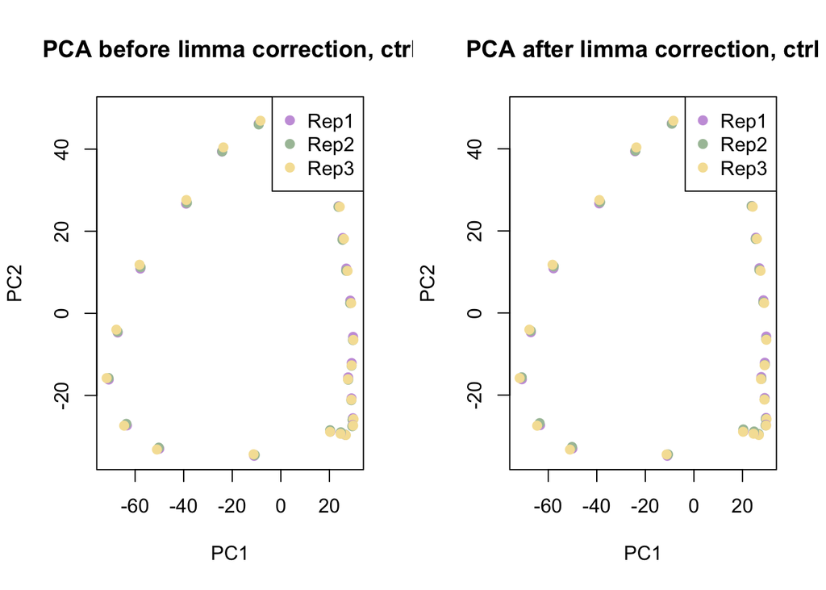

```r
#1. Prepare PCA
LC_pca_before <- prcomp(t(ctrl_expr_matrix_log), scale. = TRUE)
LC_pca_after  <- prcomp(t(L_ctrl_expr_corrected), scale. = TRUE)
# Transposing the matrix is necessary because the observations and variables are swapped

#2. plot

# next to each other
par(mfrow = c(1, 2))



# PCA before correction
plot(LC_pca_before$x[, 1:2],
     col = LC_batch_colors,
     pch = 19,
     main = "PCA before limma correction, ctrl")
legend("topright", legend = levels(LC_batch), col = LC_batch_colors, pch = 19)

# PCA after correction
plot(LC_pca_after$x[, 1:2],
     col = LC_batch_colors,
     pch = 19,
     main = "PCA after limma correction, ctrl")
legend("topright", legend = levels(LC_batch), col = LC_batch_colors, pch = 19)
```

#interpretation There is no severe change visible, also there is no distinct differences between replicates

##heatmap #expectation: before: samples are grouped by batch, there is a clear separation of batches shown in the annotation after: samples are grouped according to biological features, no separation

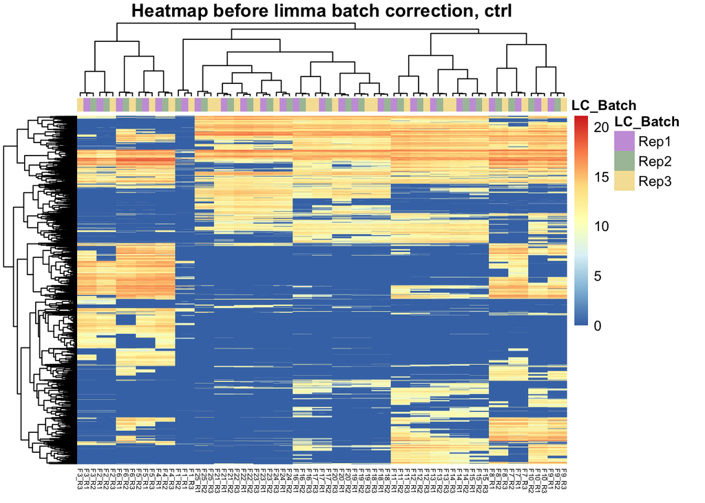

```r
#prep: Set short labels as new column names
colnames(L_ctrl_expr_corrected) <- short_labels
colnames(ctrl_expr_matrix_log) <- short_labels

#1. create annotation for Heatmap
annotation_col <- data.frame(LC_Batch = LC_batch)
rownames(annotation_col) <- colnames(ctrl_expr_matrix_log)

#2.
library(pheatmap)

# heatmap before correction
pheatmap(ctrl_expr_matrix_log,
         annotation_col = annotation_col,
         annotation_colors = list(LC_Batch = LC_batch_colors),
         main = "Heatmap before limma batch correction, ctrl",
         fontsize_col=5)
```

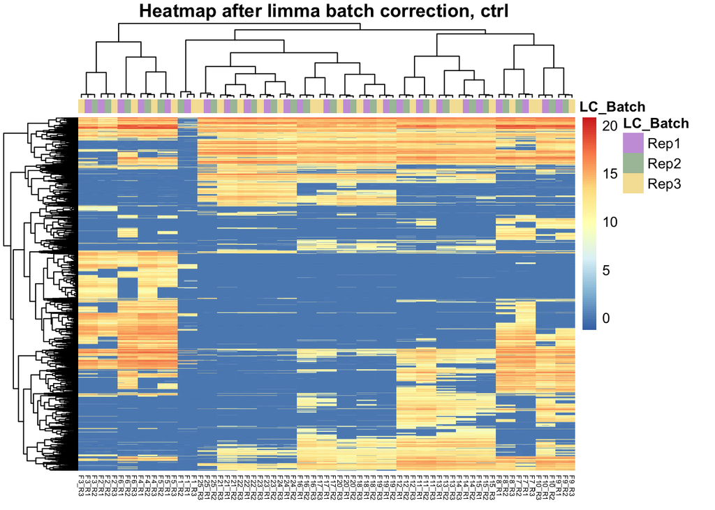

```r
# heatmap after correction
pheatmap(L_ctrl_expr_corrected,
         annotation_col = annotation_col,
         annotation_colors = list(LC_Batch = LC_batch_colors),
         main = "Heatmap after limma batch correction, ctrl ",
         fontsize_col=5)
```

#interpretation before the correction there is no major separation visible, after the correction there is a slight change visible

##protein names back

```r
#add column with protein names again
L_ctrl_expr_corrected_df <- data.frame(
  Protein = percent_ctrl_df[, 1],
L_ctrl_expr_corrected,
  check.names = FALSE                  # Prevents renaming of columns
)

colnames(L_ctrl_expr_corrected_df)
```

```
##  [1] "Protein" "F1_R1"   "F1_R2"   "F1_R3"   "F2_R1"   "F2_R2"   "F2_R3"
##  [8] "F3_R1"   "F3_R2"   "F3_R3"   "F4_R1"   "F4_R2"   "F4_R3"   "F5_R1"
## [15] "F5_R2"   "F5_R3"   "F6_R1"   "F6_R2"   "F6_R3"   "F7_R1"   "F7_R2"
## [22] "F7_R3"   "F8_R1"   "F8_R2"   "F8_R3"   "F9_R1"   "F9_R2"   "F9_R3"
## [29] "F10_R1"  "F10_R2"  "F10_R3"  "F11_R1"  "F11_R2"  "F11_R3"  "F12_R1"
## [36] "F12_R2"  "F12_R3"  "F13_R1"  "F13_R2"  "F13_R3"  "F14_R1"  "F14_R2"
## [43] "F14_R3"  "F15_R1"  "F15_R2"  "F15_R3"  "F16_R1"  "F16_R2"  "F16_R3"
## [50] "F17_R1"  "F17_R2"  "F17_R3"  "F18_R1"  "F18_R2"  "F18_R3"  "F19_R1"
## [57] "F19_R2"  "F19_R3"  "F20_R1"  "F20_R2"  "F20_R3"  "F21_R1"  "F21_R2"
## [64] "F21_R3"  "F22_R1"  "F22_R2"  "F22_R3"  "F23_R1"  "F23_R2"  "F23_R3"
## [71] "F24_R1"  "F24_R2"  "F24_R3"  "F25_R1"  "F25_R2"  "F25_R3"
```

##RNASE

##boxplot rnase Goal: Visualize data in a boxplot in order to observe first differences ##load data and creat matrix

```r
# 1. Extract expression data and save it as matrix, delete protein names
rnase_expr_matrix <- as.matrix(percent_ctrl_df[, -1])
```

##create batch vector rnase limma

```r
#1. Extract sample names to create batch labels
LR_sample_names <- colnames(rnase_expr_matrix)

#2. Create batch labels out of sample names
#create batches from replicates in order to have comparable batches
LR_batch <- sub(".*_(Rep\\d)", "\\1", LR_sample_names)
LR_batch <- factor(LR_batch, levels = c("Rep1", "Rep2", "Rep3"))

#3. Assign colors
LR_batch_colors <- c("Rep1" = "#c9a0dc", "Rep2" = "#A9C1A6", "Rep3" = "#F5E1A4")
colors <- LR_batch_colors[as.character(LR_batch)]

#4.shorten labels
short_labels <- gsub("Fraction([0-9]+)_Rep([0-9])", "F\\1_R\\2", colnames(rnase_expr_matrix))
```

##boxplot Goal: Visualize data in a boxplot in order to observe first differences

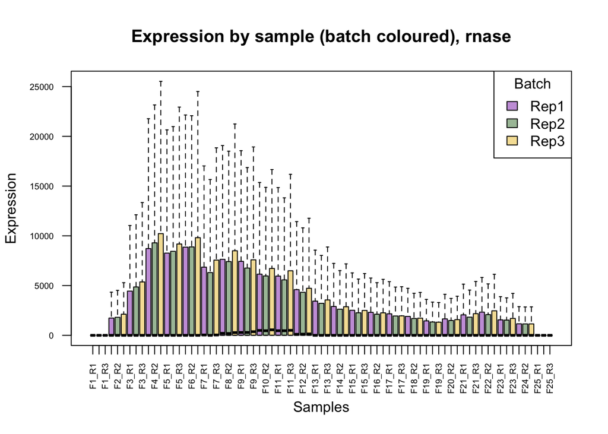

```r
#1. draw boxplot
boxplot(rnase_expr_matrix,
        main = "Expression by sample (batch coloured), rnase",
        ylab = "Expression",
        xlab = "Samples",
        las = 2,
        col = LR_batch_colors,
        outline = FALSE,
        cex.axis = 0.6,
        names = short_labels)

#2. add key
legend_labels <- c("Rep1", "Rep2", "Rep3")
legend_colors <- LR_batch_colors[legend_labels]
legend("topright",
       legend = names(LR_batch_colors),
       fill = legend_colors,
       title = "Batch")
```

#interpretation there is no distinct differences between replicates, which rules out a servere batch effect

#limma rnase first trial of removing the batch effect using limma

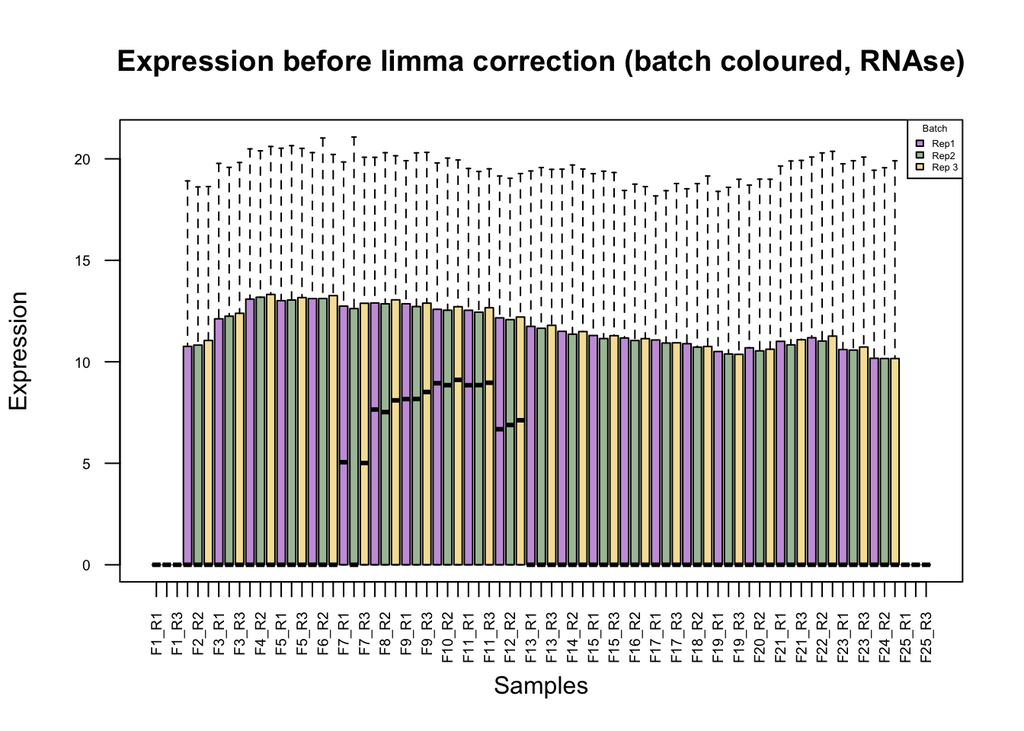

```r
library(limma)

#1. Apply a log 2 transformation
# necessary for limma, stabilizes variance, improves interpretability, reduces outlier effects
#add +1 in order to prevent log2(0)
rnase_expr_matrix_log <- log2(rnase_expr_matrix + 1)

#2. Correction with limma
L_rnase_expr_corrected <- removeBatchEffect(rnase_expr_matrix_log, LR_batch = LR_batch)

#3. Plot
#use log2-transformed matrix for comparison
# expectation
    #before: samples of one batch have similar median, but differences in batches
# Boxplot before correction

boxplot(rnase_expr_matrix_log,
        main = "Expression before limma correction (batch coloured, RNAse)",
        ylab = "Expression",
        xlab = "Samples",
        las = 2,
        col = colors,
        outline = FALSE,
        cex.axis = 0.6,
        names=short_labels)

#add key
legend_labels <- c("Rep1", "Rep2", "Rep 3")
legend("topright",
       legend = legend_labels,
       fill = LR_batch_colors,
       title = "Batch",
       cex=0.4)
```

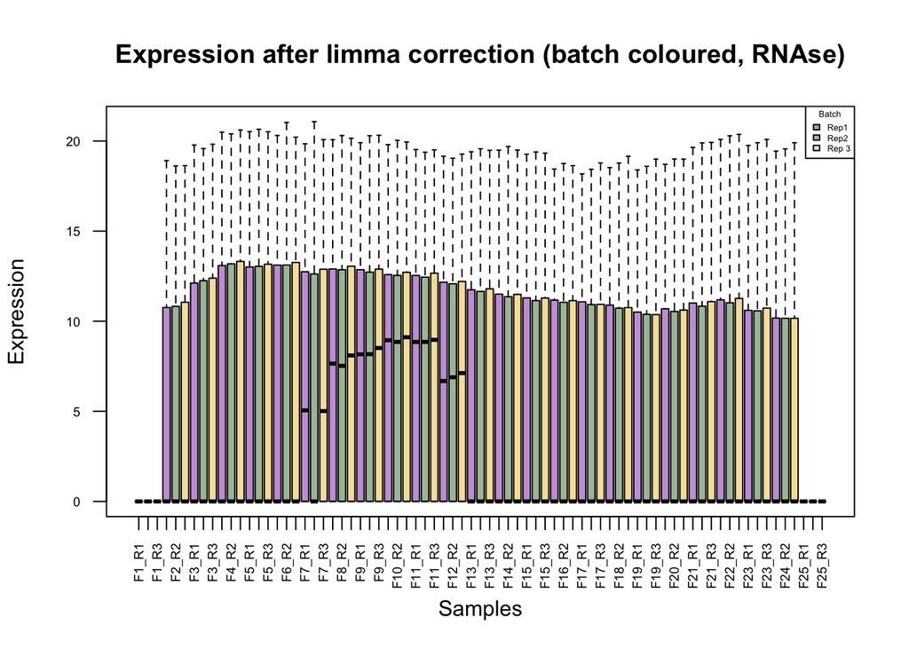

```r
# Boxplot after correction
boxplot(L_rnase_expr_corrected,
        main = "Expression after limma correction (batch coloured, RNAse)",
        ylab = "Expression",
        xlab = "Samples",
        las = 2,
        col = colors,
        outline = FALSE,
        cex.axis = 0.6,
        names=short_labels)


#add key
llegend_labels <- c("Rep1", "Rep2", "Rep 3")
legend("topright",
       legend = legend_labels,
       fill = LR_batch_colors,
       title = "Batch",
       cex=0.4)
```

#Interpretation There is no severe change visible

#more visualizing

## Batch effect pca limma rnase

#expectation before: clusters of the same batch, strong separation along principle components after: no separation visible

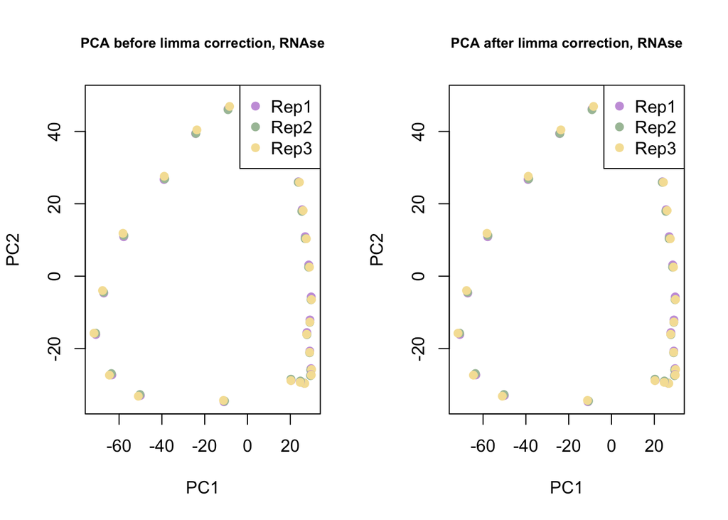

```r
#1. Prepare PCA
LR_pca_before <- prcomp(t(rnase_expr_matrix_log), scale. = TRUE)
LR_pca_after  <- prcomp(t(L_rnase_expr_corrected), scale. = TRUE)
# Transposing the matrix is necessary because the observations and variables are swapped

#2. plot
#plot next to eachother
par(mfrow = c(1, 2))


# PCA before correction
plot(LR_pca_before$x[, 1:2],
     col = colors,
     pch = 19,
     main =  "PCA before limma correction, RNAse",
     cex.main=0.8)
legend("topright", legend = levels(LR_batch), col = colors, pch = 19)

# PCA after correction
plot(LR_pca_after$x[, 1:2],
     col = colors,
     pch = 19,
     main = "PCA after limma correction, RNAse",
     cex.main=0.8)
legend("topright", legend = levels(LR_batch), col = colors, pch = 19)
```

#interpretation There is no severe change visible, also there are no distinct differences between replicates, which rules out a severe batch effect

##heatmap rnase limma #expectation: Before: Samples are grouped by batch, and there is a clear separation of batches shown in the annotation after: samples are grouped according to biological feature, no separation

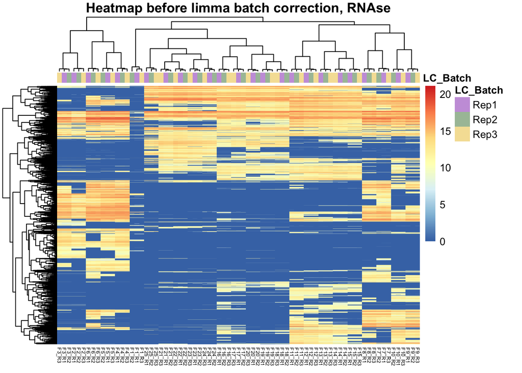

```r
#prep: Set short labels as new column names
colnames(L_rnase_expr_corrected) <- short_labels
colnames(rnase_expr_matrix_log) <- short_labels

#1. create annotation for Heatmap
annotation_col <- data.frame(LC_Batch = LC_batch)
rownames(annotation_col) <- colnames(ctrl_expr_matrix_log)

#2.
library(pheatmap)

# heatmap before correction
pheatmap(rnase_expr_matrix_log,
         annotation_col = annotation_col,
         annotation_colors = list(LC_Batch = LC_batch_colors),
         main = "Heatmap before limma batch correction, RNAse",
         fontsize_col=5)
```

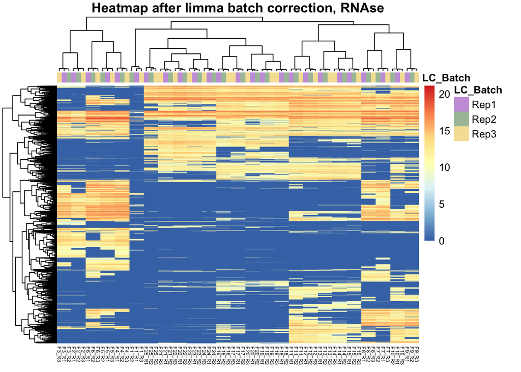

```r
# heatmap after correction
pheatmap(L_rnase_expr_corrected,
         annotation_col = annotation_col,
         annotation_colors = list(LC_Batch = LC_batch_colors),
         main = "Heatmap after limma batch correction, RNAse",
         fontsize_col=5)
```

#interpretation no change visible

```r
#add column with protein names again
rnase_expr_corrected_df <- data.frame(
  Protein = percent_ctrl_df[, 1],
  L_rnase_expr_corrected,
  check.names = FALSE                 # Prevents renaming of columns
)
```

##SVA SVA is used as alternative packages. SVA is a more flexible package as it does not need any exact batch annotation and can detect more hidden disruptive factors. For experiments with many replicates and fractions this package appears more suitable